# DDS Live Session Week 12 Assignment

Jenna Ford

7/26/2019

## Loading Libraries

```r
library(fpp2)
```

```r
library(RCurl)
library(dygraphs)
library(xts)
library(lubridate)
```

## Warm-Up: Brief Financial Data

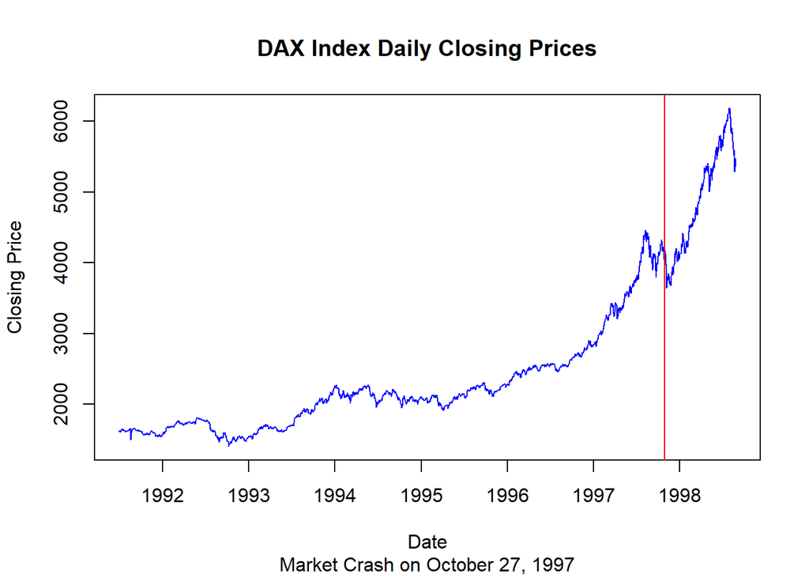

```r
dax = EuStockMarkets[,"DAX"]
plot(dax,ylab = "Closing Price", xlab = "Date", main="DAX Index Daily Closing Prices",col="blue", sub="Market Crash on October 27, 1997")

#I estimated where the market crash of Oct 27, 1997 is on the plot
abline(v=1997.823, col="red")
```

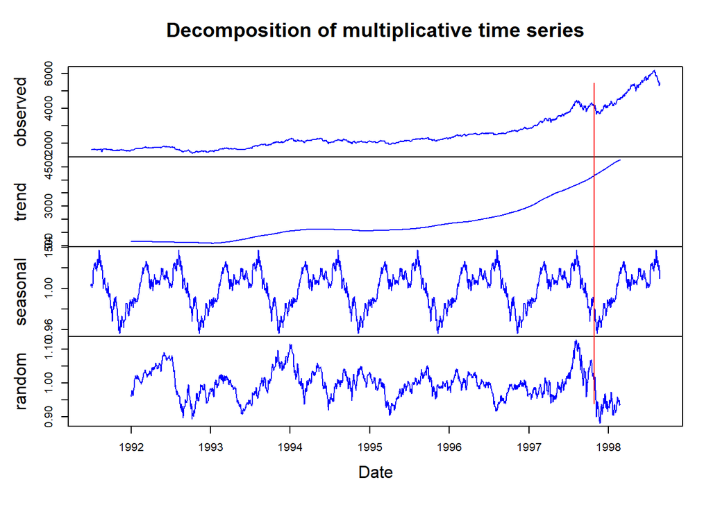

```r
decomp <- decompose(dax, type="mult")
plot(decomp,col="blue", xlab = "Date",sub="Market Crash on October 27, 1997")
abline(v=1997.823, col="red")
```

## Temperature Data

The data for this section is from the maxtemps dataset in R. It has the maximum annual temperatures for the Moorabbin Airport in Melbourne for 1971-2016. 2 models will be fitted: a simple exponential smoothing model and a damped Holt’s linear trend model.The 2 models will be compared to see which is the better fit.

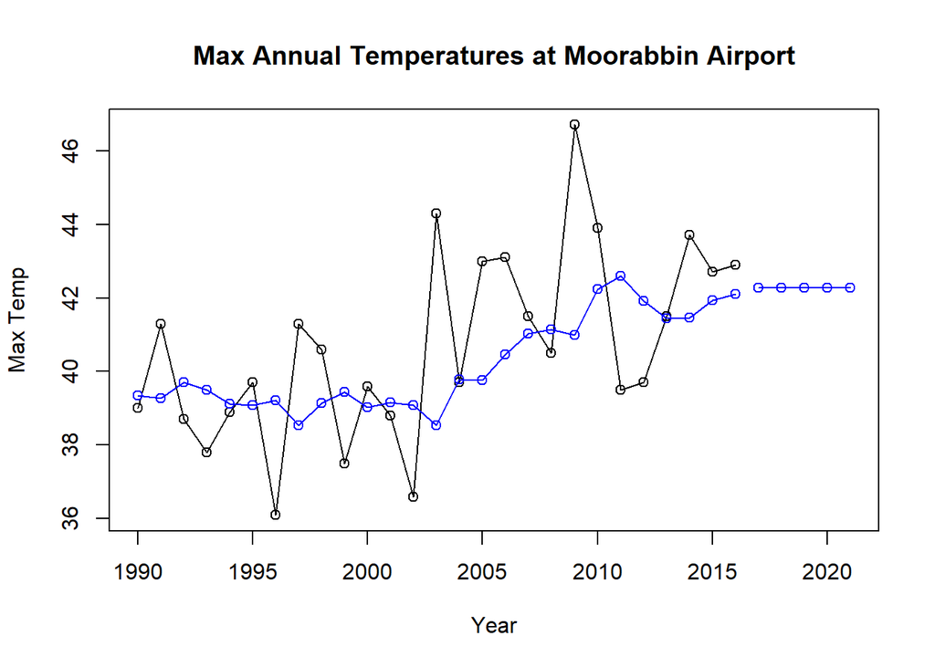

```r
#Get data for 1990 onward
temp = window(maxtemp, start = 1990)

#SES Model
fit1 = ses(temp, h = 5)
plot(temp,ylab = "Max Temp", xlab = "Year", type = "o", xlim=c(1990,2021), main="Max Annual Temperatures at Moorabbin Airport")
lines(fitted(fit1), col = "blue", type = "o")
lines(fit1$mean, col = "blue", type = "o")
```

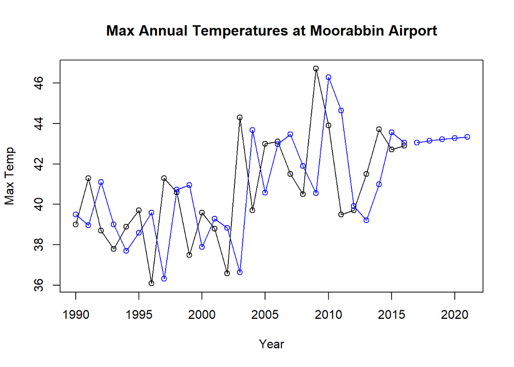

```r
#Damped Holt's Linear Model
fit2h = holt(temp, alpha = .8, beta = .2, damped = TRUE, initial="optimal", h = 5)
plot(temp,ylab = "Max Temp", xlab = "Year", type = "o", xlim=c(1990,2021), main="Max Annual Temperatures at Moorabbin Airport")
lines(fitted(fit2h), col = "blue", type= "o")
lines(fit2h$mean,col = "blue", type= "o")
```

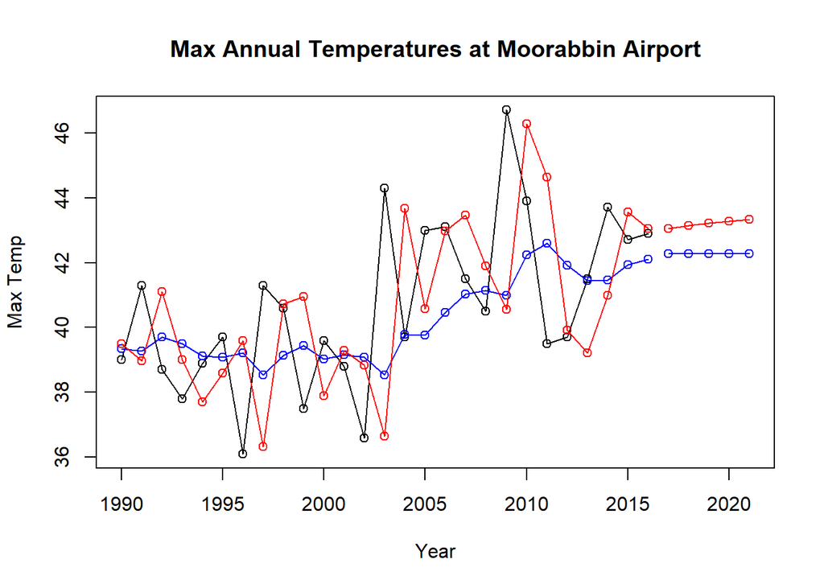

```r
#Plot together
plot(temp,ylab = "Max Temp", xlab = "Year", type = "o", xlim=c(1990,2021), main="Max Annual Temperatures at Moorabbin Airport")
lines(fitted(fit1), col = "blue", type = "o")
lines(fit1$mean, col = "blue", type = "o")
lines(fitted(fit2h), col = "red", type= "o")
lines(fit2h$mean,col = "red", type= "o")
```

```r
#Compare ASE for both models
ASE1 <- sum((fitted(fit1) - maxtemp)^2)/length(temp)
ASE2h <- sum((fitted(fit2h) - maxtemp)^2)/length(temp)

ASE1
```

```
## [1] 5.393285
```

```r
ASE2h
```

```
## [1] 8.949939
```

The ASE for the Simple exponential smoothing model was 5.39 compared to 8.95 for Holt’s damped linear model. As such, The SES model performs better using ASE.

```r
fit1$model
```

```
## Simple exponential smoothing
##
## Call:
##  ses(y = temp, h = 5)
##
##   Smoothing parameters:
##     alpha = 0.2164
##
##   Initial states:
##     l = 39.345
##
##   sigma:  2.4135
##
##      AIC     AICc      BIC
## 140.4868 141.5302 144.3743
```

```r
fit2h$model
```

```
## Damped Holt's method
##
## Call:
##  holt(y = temp, h = 5, damped = TRUE, initial = "optimal", alpha = 0.8,
##
##  Call:
##      beta = 0.2)
##
##   Smoothing parameters:
##     alpha = 0.8
##     beta  = 0.2
##     phi   = 0.8
##
##   Initial states:
##     l = 39.5644
##     b = -0.0744
##
##   sigma:  3.3142
##
##      AIC     AICc      BIC
## 156.1621 157.9802 161.3454
```

The AIC and BIC scores were both minimized in the SES model. The SES model performs better using AIC and BIC criterion. Both ASE and AIC/BIC show that SES is the better model.

## The Wands Choose the Wizard

The data for this section is wands sold by Ollivander and Gregorovitch from the Harry Potter Series. First, the 2 data sets will be combined into one timestamp series. Then a dynamic graph will be produced.

```r
URL <- getURL("https://raw.githubusercontent.com/BivinSadler/MSDS-6306-Doing-Data-Science/master/Unit%2012/Unit12TimeSeries_Ollivander.csv")
ollivander <- read.csv(text=URL, header=FALSE)
names(ollivander) <- c("date","ollivander")

URL <- getURL("https://raw.githubusercontent.com/BivinSadler/MSDS-6306-Doing-Data-Science/master/Unit%2012/Unit12TimeSeries_Gregorovitch.csv")
gregorovitch <- read.csv(text=URL, header=FALSE)
names(gregorovitch) <- c("date","gregorovitch")

ollivander$date2 <- mdy(ollivander$date)
tsollivander <- xts(ollivander$ollivander, ollivander$date2)
names(tsollivander) <- c("ollivander")

gregorovitch$date2 <- mdy(gregorovitch$date)
tsgregorovitch <- xts(gregorovitch$gregorovitch, gregorovitch$date2)
names(tsgregorovitch) <- c("gregorovitch")

combined = merge(tsollivander,tsgregorovitch)
dygraph(combined, main="Ollivander and Gregorovitch Yearly Wands Sales", xlab="Year", ylab="Wands Sold") %>% dyRangeSelector(height = 100) %>% dySeries("ollivander",color="orange") %>% dySeries("gregorovitch",color="purple") %>% dyShading(from="1995-01-01", to="1999-01-01", color="lightgray") %>% dyHighlight(highlightSeriesOpts=list(strokeWidth=3))
```

[interactive chart not shown]